# 数値計算法(5)

櫻井鉄也, 今倉暁, 二村保徳, TA 加藤駿介

2024-05-27

# 多項式補完の復習

## 復習：補完多項式の係数が満たす方程式

$n-1$ 次の多項式を
$$P_{n-1}(x) = c_0 + c_1 x + \dots + c_{n-1} x^{n-1}$$
とおいたとき

補間条件は
$$\begin{cases}
P_{n-1}(x_0) = c_0 + c_1 x_0 + \dots + c_{n-1} x_0^{n-1} = f_0 \\
P_{n-1}(x_1) = c_0 + c_1 x_1 + \dots + c_{n-1} x_1^{n-1} = f_1 \\
\quad \quad \quad \vdots \\
P_{n-1}(x_{n-1}) = c_0 + c_1 x_{n-1} + \dots + c_{n-1} x_{n-1}^{n-1} = f_{n-1}
\end{cases}$$
と表される。

## 復習：連立一次方程式への帰着

$c_0,c_1,\dots,c_{n-1}$ を未知数とする連立一次方程式
$$\begin{pmatrix}
1 & x_0 & x_0^2 & \cdots & x_0^{n-1} \\
1 & x_1 & x_1^2 & \cdots & x_1^{n-1} \\
\vdots & \vdots & & \vdots \\
1 & x_{n-1} & x_{n-1}^2 & \cdots & x_{n-1}^{n-1}
\end{pmatrix}
\begin{pmatrix}
c_0 \\
c_1 \\
\vdots \\
c_{n-1}
\end{pmatrix}
=
\begin{pmatrix}
f_0 \\
f_1 \\
\vdots \\
f_{n-1}
\end{pmatrix}$$
に帰着する。

この係数行列は**Vandermonde行列**とよばれる。

## 発展：補完法と基底関数

- 多項式の表現
  $$P_{n-1}(x_{n-1}) = c_0 + c_1 x_{n-1} + \dots + c_{n-1} x_{n-1}^{n-1} = f_{n-1}$$
  これは単項式 $1,x,x^2,\dots,x^{n-1}$ の線型結合。
  - $2x$ は $x$ に $2$ をかけて表せる$\Rightarrow$ 独立ではない
- $n$ 個の線型独立な関数 $\phi_0(x),\phi_1(x),\dots,\phi_{n-1}(x)$ の線型結合に一般化できる
  - 例
    - チェビシェフ多項式：
      $$T_0(x)=1, T_1(x)=2x, T2(x)=4x^2-1,\dots$$
    - 離散コサイン変換： $1,\cos x, \cos 2x,\dots$

# 最小二乗法

## 最小二乗近似

- 最小二乗法では標本点数$m$に対して補間多項式の次数が低いものを用いる（**$m > n$**）．

$\rightarrow$ 未知数の数と条件の数が一致しない

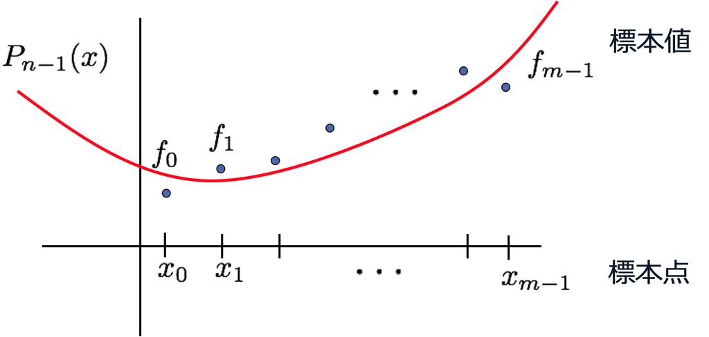

## 条件式

- 補間多項式のときと同様にして、以下のようにおく（ただし、$m > n$）

$$A =
\begin{pmatrix}
1 & x_0 & x_0^2 & \cdots & x_0^{n-1} \\
1 & x_1 & x_1^2 & \cdots & x_1^{n-1} \\
\vdots & \vdots & & \vdots \\
1 & x_{m-1} & x_{m-1}^2 & \cdots & x_{m-1}^{n-1}
\end{pmatrix},$$

$$\bm{c}=
\begin{pmatrix}
c_0 \\
c_1 \\
\vdots \\
c_{n-1}
\end{pmatrix},
\quad
\bm{f}=
\begin{pmatrix}
f_0 \\
f_1 \\
\vdots \\
f_{m-1}
\end{pmatrix}$$

## 未知数と条件式（未知数と条件式数が一致）

- わからないもの：未知数
- 満たすべき条件：方程式
  - 未知数：$x_1, x_2$
  - 条件1：$a_{11} x_1 + a_{12} x_2 = b_1$
  - 条件2：$a_{21} x_1 + a_{22} x_2 = b_2$
- 連立一次方程式
  $$\begin{pmatrix}
  a_{11} & a_{12} \\
  a_{21} & a_{22}
  \end{pmatrix}
  \begin{pmatrix}
  x_{1} \\
  x_{2}
  \end{pmatrix}
  =
  \begin{pmatrix}
  b_{1} \\
  b_{2}
  \end{pmatrix}$$

## 未知数と条件式（未知数と条件式数が不一致）

- さらに条件3
  $$a_{31} x_1 + a_{32} x_2 = b_3$$
  が加わると、方程式は過剰条件
  $$\begin{pmatrix}
  a_{11} & a_{12} \\
  a_{21} & a_{22} \\
  a_{31} & a_{32}
  \end{pmatrix}
  \begin{pmatrix}
  x_{1} \\
  x_{2}
  \end{pmatrix}
  =
  \begin{pmatrix}
  b_{1} \\
  b_{2} \\
  b_{3}
  \end{pmatrix}$$
  一般には解は存在しない

$\Rightarrow$ なるべく近い解を見つけたい

# 正規方程式

## 最小二乗法

- $A\bm{c} = \bm{f}$ とできないため、ベクトル $\bm{y}=A\bm{c}$ と $\bm{f}$ ができるだけ近くなるようにする

$\rightarrow \|\bm{y} - \bm{f}\|$ を小さくする

- $A=[\bm{a}_1,\bm{a}_2,\dots,\bm{a}_n]$ とおくと
  $$\bm{y}=A\bm{c}=c_0 \bm{a}_1+c_1 \bm{a}_2+\dots+c_{n-1} \bm{a}_n$$
- $\bm{y} - \bm{f}$ と $\bm{a}_1,\bm{a}_2,\dots,\bm{a}_n$ が直交するように $\bm{c}$ を決める

$$\bm{a}_j^{\mathrm{T}} (\bm{y} - \bm{f}) = 0,\quad(1 \le j \le n)$$

## 最小二乗法

- $\bm{y} - \bm{f}$ と $\bm{a}_1,\bm{a}_2,\dots,\bm{a}_n$ が直交
  $$\bm{a}_j^{\mathrm{T}} (\bm{y} - \bm{f}) = 0,\quad(1 \le j \le n)$$
- 行列$A^{\mathrm{T}}$ は
  $$A^{\mathrm{T}} =
  \begin{pmatrix}
  \bm{a}_1^{\mathrm{T}} \\
  \bm{a}_2^{\mathrm{T}} \\
  \vdots \\
  \bm{a}_{n-1}^{\mathrm{T}}
  \end{pmatrix}$$
- したがって、条件式は
  $$A^{\mathrm{T}} \bm{y} - A^{\mathrm{T}} \bm{f} = \bm{0}
  \Rightarrow A^{\mathrm{T}} A \bm{c} = A^{\mathrm{T}} \bm{f}$$

## 正規方程式

- 最小二乗多項式の係数は以下の関係を満たす
  $$A^{\mathrm{T}} A \bm{c} = A^{\mathrm{T}} \bm{f}$$
  この方程式を**正規方程式**とよぶ
- $A^{\mathrm{T}} A=B, A^{\mathrm{T}} \bm{f}=\bm{g}$ とおくと正規方程式は連立一次方程式
  $$B \bm{c} = \bm{g}$$
  で表される

# QR分解を用いた計算

## 列直交行列と直交行列

- $Q^{\mathrm{T}} Q = I$ を満たす $Q \in \mathbb{R}^{m \times n} (m>n)$ を**列直交行列**とよぶ
  - $m=n$ のとき、これを単に**直交行列**と呼ぶ

## QR分解の利用

- 正規方程式を直接解くと誤差が大きくなることが知られている
  - そのため、$A^{\mathrm{T}} A$ を計算しないで $\bm{c}$ を求める方法が必要となる。**$\rightarrow$QR分解の利用**
- 行列 $A \in \mathbb{R}^{m \times n}$ の列ベクトルが線形独立のとき、
  $$A=QR$$
  を満たす$Q \in \mathbb{R}^{m \times n}$と$R \in \mathbb{R}^{n \times n}$が存在する。ここで$Q$は列直交行列（$Q^{\mathrm{T}} Q = I$）、$R$は上三角で正則

## QR分解の利用

- $A$ のQR分解を用いると、正規方程式
  $$A^{\mathrm{T}} A \bm{c} = A^{\mathrm{T}} \bm{f}$$
  から
  $$(QR)^{\mathrm{T}} (QR) \bm{c} = (QR)^{\mathrm{T}} \bm{f}$$
- この左辺は
  $$(QR)^{\mathrm{T}} (QR) \bm{c} = R^{\mathrm{T}} Q^{\mathrm{T}} QR \bm{c} = R^{\mathrm{T}} R \bm{c} \quad (Q^{\mathrm{T}} Q = I)$$
- 右辺は
  $$(QR)^{\mathrm{T}} \bm{f} = R^{\mathrm{T}} Q^{\mathrm{T}} \bm{f}$$
- $R$が正則のとき
  **$$R \bm{c} = Q^{\mathrm{T}} \bm{f}$$**

## QR分解の利用

- よって$A^{\mathrm{T}} A \bm{c} = A^{\mathrm{T}} \bm{f}$のかわりに
  **$$R \bm{c} = Q^{\mathrm{T}} \bm{f}$$**
  を解けば良い
- QR分解はJuliaでは関数`qr`を用いる

```julia
  using LinearAlgebra
  Q0, R = qr(A)
  Q = Matrix(Q0)
```

- ここでの`qr`関数の第1戻り値の`Q0`は特殊なデータ型となっているため、`Matrix`関数で通常の行列（二次元配列）に変換すると良い。（特殊なデータ型については講義内容範囲を超えるため）
- `Q*R`と`A`がほぼ等しいことを確認すると良い。